```python
import torch
from torch.autograd import Variable
import torch.nn as nn
import torch.optim as optim
from fbprophet import Prophet
import numpy as np
import pandas as pd
import sklearn
from sklearn.preprocessing import StandardScaler
from sklearn.metrics import mean_squared_error
import matplotlib
import matplotlib.pyplot as plt
import time
import random

%matplotlib inline

plt.rcParams["figure.facecolor"] = "w"
plt.rcParams['figure.figsize'] = 14, 7
```

# SOYBEANS data

```python
# Data from https://www.macrotrends.net/2531/soybean-prices-historical-chart-data

soybeans_df = pd.read_csv("soybean-prices-historical-chart-data.csv")
# change date to datetime type
soybeans_df['date'] = pd.to_datetime(soybeans_df['date'])
soybeans_df.set_index('date', inplace=True)

soybeans_df.head()
```

| date | value |
| --- | --- |
| 1968-12-05 | 2.4375 |
| 1968-12-06 | 2.4475 |
| 1968-12-09 | 2.4363 |
| 1968-12-10 | 2.4375 |
| 1968-12-11 | 2.4463 |

```python
soybeans_df.tail()
```

| date | value |
| --- | --- |
| 2020-03-18 | 8.2550 |
| 2020-03-19 | 8.4325 |
| 2020-03-20 | 8.6250 |
| 2020-03-23 | 8.8400 |
| 2020-03-24 | 8.8675 |

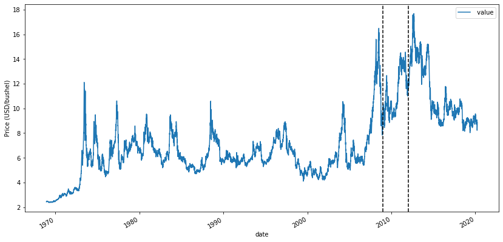

```python
# We have daily closing price (USD per bushel) of soybeans from
# Dec. 05, 1968 to Mar. 24, 2020
# Note that only 5 trading days per week

soybeans_df.plot(figsize=(14,7))
plt.ylabel("Price (USD/bushel)")
plt.axvline("2008-12-31", linestyle="--", c="black")
plt.axvline("2011-12-31", linestyle="--", c="black")
```

### Split into Training and Testing data

```python
soy_train = soybeans_df[soybeans_df.index <= "2008-12-31"]
soy_train.shape
```

```
(10089, 1)
```

```python
soy_val = soybeans_df[(soybeans_df.index > "2008-12-31") & (soybeans_df.index <= "2011-12-31")]
soy_val.shape
```

```
(756, 1)
```

```python
soy_test = soybeans_df[soybeans_df.index > "2011-12-31"]
soy_test.shape
```

```
(2072, 1)
```

### Scale the data

```python
scaler = StandardScaler()

# fit the scaler with training data
train_arr = scaler.fit_transform(soy_train)

# apply scaler to val and test
val_arr = scaler.transform(soy_val)
test_arr = scaler.transform(soy_test)
```

```python
test_arr.shape
```

```
(2072, 1)
```

### Transforming the data into sequences

```python
def sequentialize(arr, seq_len):
    """
    A function to return sliding sequences of
    feature and target from an array
    """
    x, y = [], []
    for i in range(len(arr) - seq_len):
        x_i = arr[i : (i + seq_len)]
        y_i = arr[(i + 1) : (i + seq_len + 1)]
        x.append(x_i)
        y.append(y_i)
    x_arr = np.array(x).reshape(-1, seq_len)
    y_arr = np.array(y).reshape(-1, seq_len)
    x_var = Variable(torch.from_numpy(x_arr).float())
    y_var = Variable(torch.from_numpy(y_arr).float())

    return x_var, y_var
```

```python
# set the sequence length
# 60 trading days = 1 quarter
seq_len = 60

x_train, y_train = sequentialize(train_arr, seq_len)
x_val, y_val = sequentialize(val_arr, seq_len)
x_test, y_test = sequentialize(test_arr, seq_len)
```

```python
x_test.shape
```

```
torch.Size([2012, 60])
```

```python
def plot_sequence(axes, i, x_train, y_train, seq_no):
    window = len(x_train[0])
    axes[i].set_title("Sequence %d" % (seq_no + 1))
    axes[i].set_xlabel("Time Bars")
    axes[i].set_ylabel("Scaled Price")
    axes[i].plot(range(window), x_train[seq_no].cpu().numpy(), color="r", label="Feature")
    axes[i].plot(range(1, (window + 1)), y_train[seq_no].cpu().numpy(), color="b", label="Target")
    axes[i].legend()
```

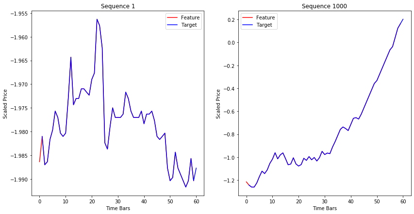

```python
fig, axes = plt.subplots(nrows=1, ncols=2, figsize=(14, 7))
plot_sequence(axes, 0, x_train, y_train, 0)
plot_sequence(axes, 1, x_train, y_train, 999)
```

# LSTM Neural Network

```python
class LSTM(nn.Module):
    def __init__(self, input_size, hidden_size, output_size):
        super(LSTM, self).__init__()
        self.input_size = input_size
        self.hidden_size = hidden_size
        self.output_size = output_size
        self.lstm = nn.LSTMCell(self.input_size, self.hidden_size)
        self.linear = nn.Linear(self.hidden_size, self.output_size)

    def forward(self, input, future=0, y=None):
        outputs = []

        # reset the state of LSTM
        # the state is kept till the end of the sequence
        h_t = torch.zeros(input.size(0), self.hidden_size, dtype=torch.float32)
        c_t = torch.zeros(input.size(0), self.hidden_size, dtype=torch.float32)

        for i, input_t in enumerate(input.chunk(input.size(1), dim=1)):
            h_t, c_t = self.lstm(input_t, (h_t, c_t))
            output = self.linear(h_t)
            outputs += [output]

        for i in range(future):
            if y is not None and random.random() > 0.5:
                output = y[:, [i]] # teacher forcing
            h_t, c_t = self.lstm(output, (h_t, c_t))
            output = self.linear(h_t)
            outputs += [output]

        outputs = torch.stack(outputs, 1).squeeze(2)
        return outputs
```

```python
class Optimization:
    """ A helper class to train, test and diagnose the LSTM"""

    def __init__(self, model, loss_fn, optimizer, scheduler):
        self.model = model
        self.loss_fn = loss_fn
        self.optimizer = optimizer
        self.scheduler = scheduler
        self.train_losses = []
        self.val_losses = []
        self.futures = []

    @staticmethod
    def generate_batch_data(x, y, batch_size):
        for batch, i in enumerate(range(0, len(x) - batch_size, batch_size)):
            x_batch = x[i : i + batch_size]
            y_batch = y[i : i + batch_size]
            yield x_batch, y_batch, batch

    def train(
        self,
        x_train,
        y_train,
        x_val=None,
        y_val=None,
        batch_size=100,
        n_epochs=15,
        do_teacher_forcing=None,
    ):
        seq_len = x_train.shape[1]
        for epoch in range(n_epochs):
            start_time = time.time()
            self.futures = []

            train_loss = 0
            for x_batch, y_batch, batch in self.generate_batch_data(x_train, y_train, batch_size):
                y_pred = self._predict(x_batch, y_batch, seq_len, do_teacher_forcing)
                self.optimizer.zero_grad()
                loss = self.loss_fn(y_pred, y_batch)
                loss.backward()
                self.optimizer.step()
                train_loss += loss.item()
            self.scheduler.step()
            train_loss /= batch
            self.train_losses.append(train_loss)

            self._validation(x_val, y_val, batch_size)

            elapsed = time.time() - start_time
            print(
                "Epoch %d Train loss: %.2f. Validation loss: %.2f. Avg future: %.2f. Elapsed time: %.2fs."
                % (epoch + 1, train_loss, self.val_losses[-1], np.average(self.futures), elapsed)
            )

    def _predict(self, x_batch, y_batch, seq_len, do_teacher_forcing):
        if do_teacher_forcing:
            future = random.randint(1, int(seq_len) / 2)
            limit = x_batch.size(1) - future
            y_pred = self.model(x_batch[:, :limit], future=future, y=y_batch[:, limit:])
        else:
            future = 0
            y_pred = self.model(x_batch)
        self.futures.append(future)
        return y_pred

    def _validation(self, x_val, y_val, batch_size):
        if x_val is None or y_val is None:
            return
        with torch.no_grad():
            val_loss = 0
            for x_batch, y_batch, batch in self.generate_batch_data(x_val, y_val, batch_size):
                y_pred = self.model(x_batch)
                loss = self.loss_fn(y_pred, y_batch)
                val_loss += loss.item()
            val_loss /= batch
            self.val_losses.append(val_loss)

    def evaluate(self, x_test, y_test, batch_size, future=1):
        with torch.no_grad():
            test_loss = 0
            actual, predicted = [], []
            for x_batch, y_batch, batch in self.generate_batch_data(x_test, y_test, batch_size):
                y_pred = self.model(x_batch, future=future)
                y_pred = (
                    y_pred[:, -len(y_batch) :] if y_pred.shape[1] > y_batch.shape[1] else y_pred
                )
                loss = self.loss_fn(y_pred, y_batch)
                test_loss += loss.item()
                actual += torch.squeeze(y_batch[:, -1]).data.cpu().numpy().tolist()
                predicted += torch.squeeze(y_pred[:, -1]).data.cpu().numpy().tolist()
            test_loss /= batch
            return actual, predicted, test_loss

    def plot_losses(self):
        plt.plot(self.train_losses, label="Training loss")
        plt.plot(self.val_losses, label="Validation loss")
        plt.legend()
        plt.title("Losses")
```

```python
def generate_sequence(scaler, model, x_sample, future=1000):
    """ Generate future values for x_sample with the model """
    y_pred_tensor = model(x_sample, future=future)
    y_pred = y_pred_tensor.cpu().tolist()
    y_pred = scaler.inverse_transform(y_pred)
    return y_pred

def to_dataframe(actual, predicted):
    return pd.DataFrame({"actual": actual, "predicted": predicted})


def inverse_transform(scalar, df, columns):
    for col in columns:
        df[col] = scaler.inverse_transform(df[col])
    return df
```

## Training the LSTM

```python
lstm_1 = LSTM(input_size=1, hidden_size=30, output_size=1)

loss_fun = nn.MSELoss()

optimizer_1 = optim.Adam(lstm_1.parameters(), lr=1e-3)
scheduler_1 = optim.lr_scheduler.StepLR(optimizer_1, step_size=5, gamma=0.1)

optimization_1 = Optimization(lstm_1, loss_fun, optimizer_1, scheduler_1)
```

```python
optimization_1.train(x_train,
                     y_train,
                     x_val,
                     y_val,
                     do_teacher_forcing=True)
```

```
Epoch 1 Train loss: 0.74. Validation loss: 4.31. Avg future: 16.04. Elapsed time: 4.43s.
Epoch 2 Train loss: 0.31. Validation loss: 2.10. Avg future: 16.36. Elapsed time: 4.27s.
Epoch 3 Train loss: 0.16. Validation loss: 1.19. Avg future: 15.34. Elapsed time: 4.38s.
Epoch 4 Train loss: 0.09. Validation loss: 0.68. Avg future: 14.07. Elapsed time: 4.38s.
Epoch 5 Train loss: 0.06. Validation loss: 0.42. Avg future: 14.82. Elapsed time: 4.33s.
Epoch 6 Train loss: 0.05. Validation loss: 0.40. Avg future: 14.99. Elapsed time: 4.35s.
Epoch 7 Train loss: 0.05. Validation loss: 0.39. Avg future: 16.33. Elapsed time: 4.37s.
Epoch 8 Train loss: 0.05. Validation loss: 0.37. Avg future: 16.42. Elapsed time: 4.42s.
Epoch 9 Train loss: 0.04. Validation loss: 0.35. Avg future: 15.18. Elapsed time: 4.47s.
Epoch 10 Train loss: 0.04. Validation loss: 0.33. Avg future: 15.57. Elapsed time: 4.14s.
Epoch 11 Train loss: 0.04. Validation loss: 0.33. Avg future: 15.17. Elapsed time: 4.02s.
Epoch 12 Train loss: 0.04. Validation loss: 0.33. Avg future: 14.59. Elapsed time: 4.17s.
Epoch 13 Train loss: 0.04. Validation loss: 0.33. Avg future: 16.32. Elapsed time: 4.52s.
Epoch 14 Train loss: 0.04. Validation loss: 0.33. Avg future: 15.06. Elapsed time: 4.34s.
Epoch 15 Train loss: 0.04. Validation loss: 0.32. Avg future: 14.33. Elapsed time: 4.32s.
```

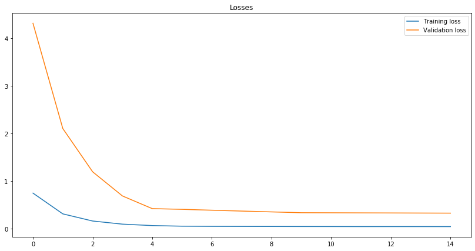

```python
optimization_1.plot_losses()
```

## Evaluation

```python
# Accuracy metrics
def forecast_accuracy(forecast, actual):
    mape = np.mean(np.abs(forecast - actual)/np.abs(actual))  # MAPE
    me = np.mean(forecast - actual)             # ME
    mae = np.mean(np.abs(forecast - actual))    # MAE
    mpe = np.mean((forecast - actual)/actual)   # MPE
    rmse = np.mean((forecast - actual)**2)**.5  # RMSE
    corr = np.corrcoef(forecast, actual)[0,1]   # corr
    mins = np.amin(np.hstack([forecast[:,None],
                              actual[:,None]]), axis=1)
    maxs = np.amax(np.hstack([forecast[:,None],
                              actual[:,None]]), axis=1)
    minmax = 1 - np.mean(mins/maxs)             # minmax
    return({'mape':mape, 'me':me, 'mae': mae,
            'mpe': mpe, 'rmse':rmse,
            'corr':corr, 'minmax':minmax})
```

```
Test loss 0.5388
```

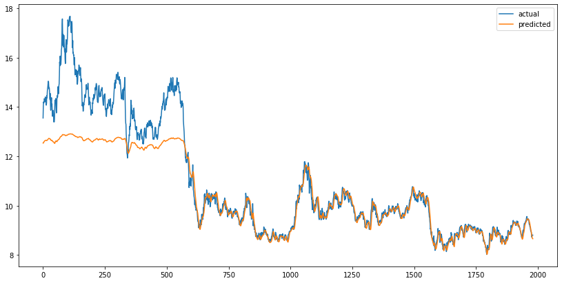

```python
actual_1, predicted_1, test_loss_1 = optimization_1.evaluate(x_test, y_test, future=0, batch_size=60)

df_result_1 = to_dataframe(actual_1, predicted_1)
df_result_1 = inverse_transform(scaler, df_result_1, ['actual', 'predicted'])

df_result_1.plot(figsize=(14, 7))
print("Test loss %.4f" % test_loss_1)
```

```python
len(predicted_1)
```

```
1980
```

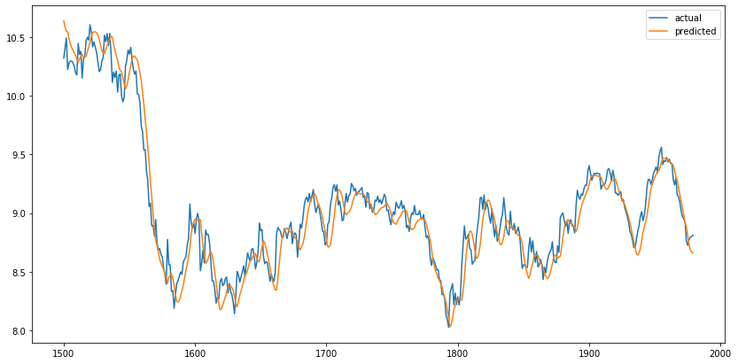

```python
df_result_1.iloc[1500:2000].plot(figsize=(14, 7))
```

```python
df_result_1.shape
```

```
(1980, 2)
```

```python
df_result_1.head()
```

[output not shown]

# Soy Prophet

```python
# set up training dataframe
soy_df_train = soybeans_df[soybeans_df.index < "2011-12-31"]
soy_df_train = soy_df_train.reset_index()
soy_df_train.rename(columns= {'date':'ds', ' value':'y'}, inplace=True)

soy_df_train.shape
```

```
(10845, 2)
```

## Training the Prophet

```python
# fit a Prophet model
soy_proph = Prophet()
soy_proph.fit(soy_df_train)
```

```
INFO:fbprophet:Disabling daily seasonality. Run prophet with daily_seasonality=True to override this.
```

```
<fbprophet.forecaster.Prophet at 0x14955dbb0>
```

```python
# dataframe with all dates
soy_future = soybeans_df.reset_index()[['date']].rename(columns={'date':'ds'})

soy_future.shape
```

```
(12917, 1)
```

## Predictions

```python
soy_forecast = soy_proph.predict(soy_future)

soy_forecast[['ds', 'yhat', 'yhat_lower', 'yhat_upper']].tail(10)
```

|  | ds | yhat | yhat_lower | yhat_upper |
| --- | --- | --- | --- | --- |
| 12907 | 2020-03-11 | 19.596125 | 10.523469 | 28.818372 |
| 12908 | 2020-03-12 | 19.598852 | 10.387402 | 28.372571 |
| 12909 | 2020-03-13 | 19.613396 | 9.990796 | 28.433586 |
| 12910 | 2020-03-16 | 19.625025 | 10.215240 | 28.471737 |
| 12911 | 2020-03-17 | 19.626175 | 10.173902 | 28.767561 |
| 12912 | 2020-03-18 | 19.638000 | 10.684158 | 28.466854 |
| 12913 | 2020-03-19 | 19.640543 | 10.156919 | 28.784956 |
| 12914 | 2020-03-20 | 19.654719 | 10.260908 | 28.585412 |
| 12915 | 2020-03-23 | 19.663933 | 10.406380 | 28.482858 |
| 12916 | 2020-03-24 | 19.663818 | 10.000602 | 28.690032 |

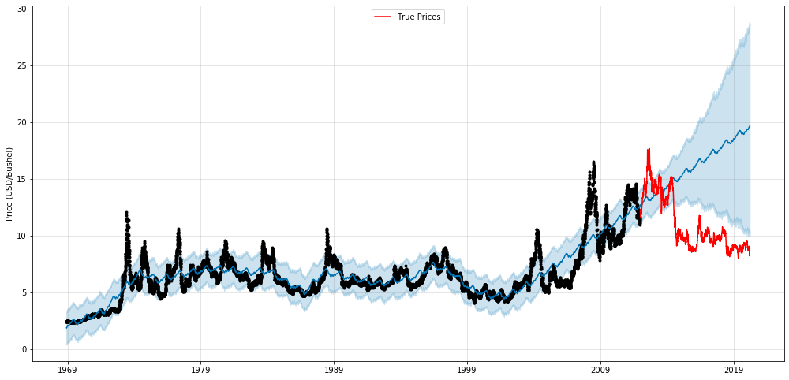

```python
# plot the forecast
fig2 = soy_proph.plot(soy_forecast, figsize=(14,7))
plt.plot(soybeans_df[soybeans_df.index >= "2011-12-31"],
        c='r', linestyle='-', label='True Prices')
plt.ylabel("Price (USD/Bushel)")
plt.xlabel(None)
plt.legend(loc='upper center')
```

## Evaluation

```python
mean_squared_error(soy_test[[' value']], soy_forecast[soy_forecast['ds'] >= "2011-12-31"][['yhat']])
```

```
43.73900379671112
```

```python
soy_fc = soy_forecast[soy_forecast['ds'] >= "2011-12-31"][['yhat']]
soy_fc = soy_fc.set_index(soy_test.index)
```

```python
forecast_accuracy(soy_fc['yhat'], soy_test[' value'])
```

```
{'mape': 0.5916822298103198,
 'me': 5.192992053895968,
 'mae': 5.652270559048026,
 'mpe': 0.5621477540369507,
 'rmse': 6.613546990587662,
 'corr': -0.8030410213847158,
 'minmax': 0.32790726042824525}
```

# ARIMA

```python
from statsmodels.tsa.arima_model import ARIMA
import pmdarima as pm
from statsmodels.tsa.stattools import acf, adfuller
from statsmodels.graphics.tsaplots import plot_acf, plot_pacf
from numpy import log
```

```python
# null hypothesis is that the series is not stationary
result = adfuller(soybeans_df)
print('ADF Statistic: %f' % result[0])
print('p-value: %f' % result[1])
```

```
ADF Statistic: -3.325553
p-value: 0.013774
```

Since the p-value for the ADF is less than 0.05, we reject the null hypothesis and conclude that the series is stationary. We should set d=0.

```python
# TRAINING DATA for the model
arima_train = soy_train.append(soy_val)
```

# Automatic Step-wise AIC Criterion Model Selection

```python
# fit the model
model = pm.auto_arima(arima_train, start_p=1, start_q=1,
                      test='adf',       # use adftest to find optimal 'd'
                      max_p=3, max_q=3, # maximum p and q
                      m=1,              # frequency of series
                      d=None,           # let model determine 'd'
                      seasonal=False,   # No Seasonality
                      start_P=0,
                      D=0,
                      trace=False,
                      error_action='ignore',
                      suppress_warnings=True,
                      stepwise=True)

print(model.summary())
```

```
                               SARIMAX Results
==============================================================================
Dep. Variable:                      y   No. Observations:                10845
Model:               SARIMAX(2, 0, 0)   Log Likelihood                7764.210
Date:                Thu, 26 Mar 2020   AIC                         -15520.419
Time:                        23:03:06   BIC                         -15491.254
Sample:                             0   HQIC                        -15510.587
                              - 10845
Covariance Type:                  opg
==============================================================================
                 coef    std err          z      P>|z|      [0.025      0.975]
------------------------------------------------------------------------------
intercept      0.0091      0.003      3.173      0.002       0.003       0.015
ar.L1          1.0930      0.005    218.276      0.000       1.083       1.103
ar.L2         -0.0944      0.005    -18.929      0.000      -0.104      -0.085
sigma2         0.0140   8.03e-05    174.044      0.000       0.014       0.014
===================================================================================
Ljung-Box (Q):                      176.39   Jarque-Bera (JB):             46332.85
Prob(Q):                              0.00   Prob(JB):                         0.00
Heteroskedasticity (H):               1.43   Skew:                            -0.30
Prob(H) (two-sided):                  0.00   Kurtosis:                        13.11
===================================================================================

Warnings:
[1] Covariance matrix calculated using the outer product of gradients (complex-step).
```

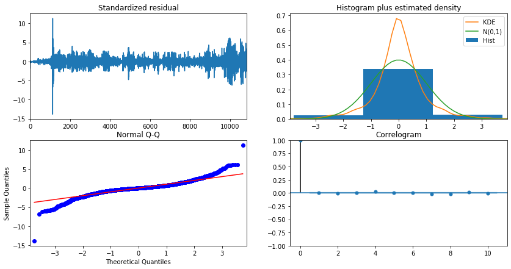

```python
model.plot_diagnostics()
plt.show()
```

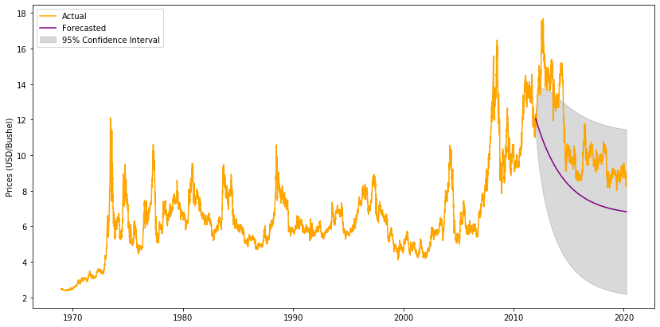

```python
# Forecast
n_periods = len(soy_test)
fc, confint = model.predict(n_periods=n_periods, return_conf_int=True)
index_of_fc = soy_test.index

# make series for plotting purpose
fc_series = pd.Series(fc, index=index_of_fc)
lower_series = pd.Series(confint[:, 0], index=index_of_fc)
upper_series = pd.Series(confint[:, 1], index=index_of_fc)

# Plot
plt.plot(soybeans_df, label="Actual", color='orange')
plt.plot(fc_series, color='purple', label="Forecasted")
plt.fill_between(lower_series.index,
                 lower_series,
                 upper_series,
                 color='k', alpha=.15, label="95% Confidence Interval")

plt.legend()
plt.ylabel("Prices (USD/Bushel)")
plt.show()
```

```python
forecast_accuracy(fc, soy_test[' value'])
```

```
{'mape': 0.23755192330499977,
 'me': -2.707099788008567,
 'mae': 2.70819877193838,
 'mpe': -0.23745841291325964,
 'rmse': 3.0267877256232953,
 'corr': 0.8516696268649069,
 'minmax': 0.23755099054170092}
```

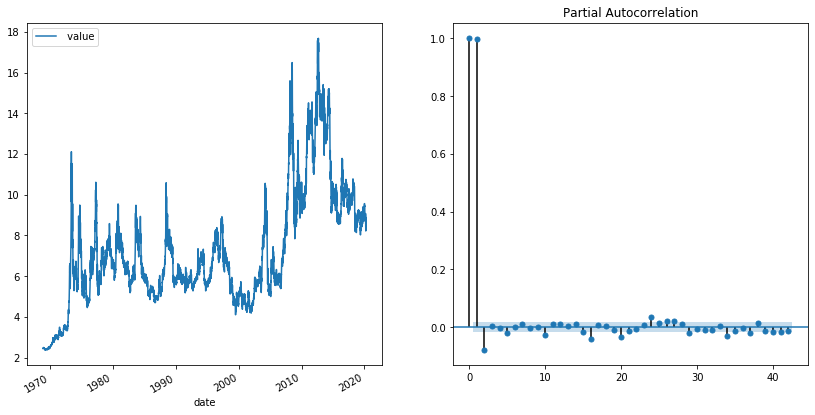

```python
# PACF plot of series
fig, axes = plt.subplots(1, 2, figsize=(14,7))
soybeans_df.plot(ax=axes[0])
plot_pacf(soybeans_df, ax=axes[1])

plt.show()
```

Partial Autocorrelation looks significant up until Lag 2, so we'll fix p=2.

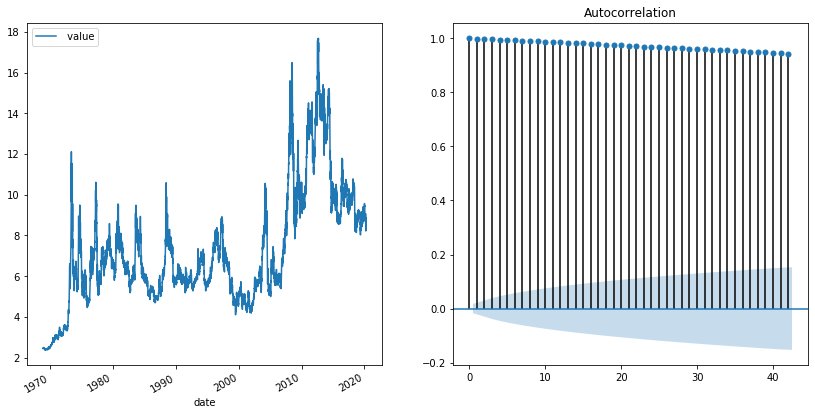

```python
# ACF plot of series
fig, axes = plt.subplots(1, 2, figsize=(14,7))
soybeans_df.plot(ax=axes[0])
plot_acf(soybeans_df.dropna(), ax=axes[1])

plt.show()
```

It looks like we need 40 MA terms to remove autocorrelation in the series. This makes me suspicious.

# COVID-19 Deaths

```python
# load the Covid-19 deaths dataset
deaths_df = pd.read_csv("time_series_covid_19_deaths.csv")
# keep only the date columns
deaths_df = deaths_df.drop(columns=['Province/State', 'Country/Region',
                       'Lat', 'Long'])

# aggregate the deaths from each Country by date
deaths_df = deaths_df.apply("sum", axis=0)
# set index to datetime type
deaths_df = deaths_df.reindex(pd.to_datetime(deaths_df.index))
# fix value for last date
deaths_df.at['2020-03-23'] = 16513

deaths_df.tail()
```

```
2020-03-19     9867.0
2020-03-20    11299.0
2020-03-21    12973.0
2020-03-22    14632.0
2020-03-23    16513.0
dtype: float64
```

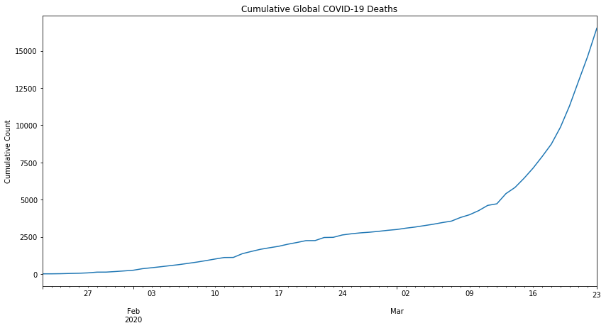

```python
# we have data from Jan. 22, 2020 to Mar. 23, 2020
deaths_df.plot(figsize=(14,7))
plt.title('Cumulative Global COVID-19 Deaths')
plt.ylabel("Cumulative Count")
```

## We use Prophet for prediction

```python
# use entire data as training set
# convert Series to Dataframe
deaths_train = deaths_df.reset_index(name='y')
deaths_train.rename(columns = {'index':'ds'}, inplace=True)

deaths_train.tail()
```

|  | ds | y |
| --- | --- | --- |
| 57 | 2020-03-19 | 9867.0 |
| 58 | 2020-03-20 | 11299.0 |
| 59 | 2020-03-21 | 12973.0 |
| 60 | 2020-03-22 | 14632.0 |
| 61 | 2020-03-23 | 16513.0 |

```python
# fit a Prophet object
proph = Prophet()
proph.fit(deaths_train)
```

```
INFO:fbprophet:Disabling yearly seasonality. Run prophet with yearly_seasonality=True to override this.
INFO:fbprophet:Disabling daily seasonality. Run prophet with daily_seasonality=True to override this.
```

```
<fbprophet.forecaster.Prophet at 0x132b544c0>
```

```python
# extend dataframe into the future
future = proph.make_future_dataframe(periods=7)
future.tail(7)
```

|  | ds |
| --- | --- |
| 62 | 2020-03-24 |
| 63 | 2020-03-25 |
| 64 | 2020-03-26 |
| 65 | 2020-03-27 |
| 66 | 2020-03-28 |
| 67 | 2020-03-29 |
| 68 | 2020-03-30 |

```python
# make predictions on the extended dataframe
forecast = proph.predict(future)
forecast[['ds', 'yhat']].tail(7)
```

|  | ds | yhat |
| --- | --- | --- |
| 62 | 2020-03-24 | 13243.194185 |
| 63 | 2020-03-25 | 13909.864033 |
| 64 | 2020-03-26 | 14533.396365 |
| 65 | 2020-03-27 | 15236.150545 |
| 66 | 2020-03-28 | 15958.659742 |
| 67 | 2020-03-29 | 16698.507433 |
| 68 | 2020-03-30 | 17421.810647 |

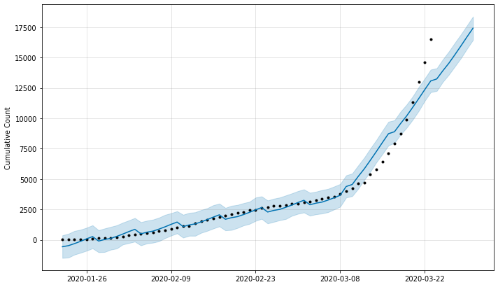

```python
# plot the forecast
fig1 = proph.plot(forecast)
plt.ylabel("Cumulative Count")
plt.xlabel(None)
```

```python
forecast_accuracy(forecast[forecast['ds'] < "2020-03-24"]['yhat'], deaths_train.y)
```

```
{'mape': 1.518310807588448,
 'me': 0.0009635825033236019,
 'mae': 436.8262035388594,
 'mpe': -1.2223739642312086,
 'rmse': 739.411210143366,
 'corr': 0.9790403951485142,
 'minmax': 1.4599619820168903}
```

### COVID-19 Deaths Analysis

Because we only 62 days' worth of observations, a machine learning algorithm such as a LSTM Neural Network would not be appropriate. It might perfectly memorize the data and overfit, generalizing poorly to predict cumulative deaths for future dates. I decided instead to try the Prophet model developed by Facebook's Core Data Science team. It uses an additive model to forecast time series data. According to the developers, "It works best with time series that have strong seasonal effects and several seasons of historical data. Prophet is robust to missing data and shifts in the trend, and typically handles outliers well."

The plot of observations seems to display an exponential growth. However, the Prophet's predictions do not follow an exponential relationship. Rather, from Jan. 22 to Mar. 8, it looks like it the forecast is trying to capture a linear trend with weekly effects, which is why we see local optima occuring every seven days. From Mar. 8 to Mar. 30, the predictions again generally follow a linear trend with a greater slope and weekly effects (there are still peaks in the forecast occuring every seven days).

Prophet performs quite well (perhaps predicting weekly effects where there are none) for dates up until Mar. 8, after which the linear growth will severely underestimate the true cumulative deaths from COVID-19. I do not recommend the Prophet model for predicting global deaths from COVID-19. Another model that incorporates an exponential shape assumption would be more appropriate.